# Análisis de enfermedades cardiovasculares

## 1- LECTURA DE LOS DATOS

```python
# Se importa la librería de pandas
import pandas as pd
import numpy as np

# Leemos el fichero y lo guardamos en el DataFrame corazon
url ="https://archive.ics.uci.edu/ml/machine-learning-databases/heart-disease/processed.cleveland.data"
corazon = pd.read_csv(url, header=None)

# Se agrega nombre de columnas
nombres_columnas=["Age","Sex","Pain","TRestBPS","Chol","FastSugar","restECG","MaxHeartRate","InducedAngina","OldPeak","Slope","VesselsColored","thal","HeartCondition"]
corazon.columns=nombres_columnas

# Se transforma la variable target multiclase en binaria
corazon['HeartCondition'].replace(1.0,"1",inplace=True)
corazon['HeartCondition'].replace(2.0,"1",inplace=True)
corazon['HeartCondition'].replace(3.0,"1",inplace=True)
corazon['HeartCondition'].replace(4.0,"1",inplace=True)

#Tamaño del dataframe
print(corazon.shape)

#Visualización de primeros 5 registros
corazon.head()
```

```
(303, 14)
```

|  | Age | Sex | Pain | TRestBPS | Chol | FastSugar | restECG | MaxHeartRate | InducedAngina | OldPeak | Slope | VesselsColored | thal | HeartCondition |
| --- | --- | --- | --- | --- | --- | --- | --- | --- | --- | --- | --- | --- | --- | --- |
| 0 | 63.0 | 1.0 | 1.0 | 145.0 | 233.0 | 1.0 | 2.0 | 150.0 | 0.0 | 2.3 | 3.0 | 0.0 | 6.0 | 0 |
| 1 | 67.0 | 1.0 | 4.0 | 160.0 | 286.0 | 0.0 | 2.0 | 108.0 | 1.0 | 1.5 | 2.0 | 3.0 | 3.0 | 1 |
| 2 | 67.0 | 1.0 | 4.0 | 120.0 | 229.0 | 0.0 | 2.0 | 129.0 | 1.0 | 2.6 | 2.0 | 2.0 | 7.0 | 1 |
| 3 | 37.0 | 1.0 | 3.0 | 130.0 | 250.0 | 0.0 | 0.0 | 187.0 | 0.0 | 3.5 | 3.0 | 0.0 | 3.0 | 0 |
| 4 | 41.0 | 0.0 | 2.0 | 130.0 | 204.0 | 0.0 | 2.0 | 172.0 | 0.0 | 1.4 | 1.0 | 0.0 | 3.0 | 0 |

## 2- EXPLORACIÓN DE DATOS

```python
corazon.describe()
```

|  | Age | Sex | Pain | TRestBPS | Chol | FastSugar | restECG | MaxHeartRate | InducedAngina | OldPeak | Slope |
| --- | --- | --- | --- | --- | --- | --- | --- | --- | --- | --- | --- |
| count | 303.000000 | 303.000000 | 303.000000 | 303.000000 | 303.000000 | 303.000000 | 303.000000 | 303.000000 | 303.000000 | 303.000000 | 303.000000 |
| mean | 54.438944 | 0.679868 | 3.158416 | 131.689769 | 246.693069 | 0.148515 | 0.990099 | 149.607261 | 0.326733 | 1.039604 | 1.600660 |
| std | 9.038662 | 0.467299 | 0.960126 | 17.599748 | 51.776918 | 0.356198 | 0.994971 | 22.875003 | 0.469794 | 1.161075 | 0.616226 |
| min | 29.000000 | 0.000000 | 1.000000 | 94.000000 | 126.000000 | 0.000000 | 0.000000 | 71.000000 | 0.000000 | 0.000000 | 1.000000 |
| 25% | 48.000000 | 0.000000 | 3.000000 | 120.000000 | 211.000000 | 0.000000 | 0.000000 | 133.500000 | 0.000000 | 0.000000 | 1.000000 |
| 50% | 56.000000 | 1.000000 | 3.000000 | 130.000000 | 241.000000 | 0.000000 | 1.000000 | 153.000000 | 0.000000 | 0.800000 | 2.000000 |
| 75% | 61.000000 | 1.000000 | 4.000000 | 140.000000 | 275.000000 | 0.000000 | 2.000000 | 166.000000 | 1.000000 | 1.600000 | 2.000000 |
| max | 77.000000 | 1.000000 | 4.000000 | 200.000000 | 564.000000 | 1.000000 | 2.000000 | 202.000000 | 1.000000 | 6.200000 | 3.000000 |

**Balanceo del dataset**

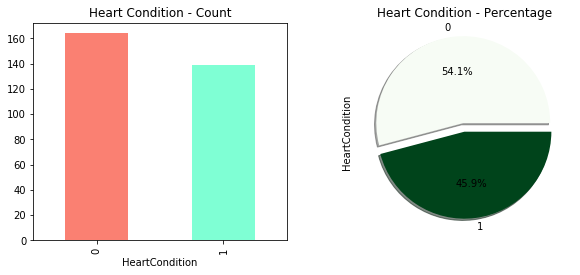

```python
# Se verifica que el dataset esté balanceado con cantidades similares de los valores que puedo tomar el target:
import matplotlib.pyplot as plt

plt.figure(figsize=(10,4))

plt.subplot(1,2,1)
corazon.HeartCondition.value_counts().plot(kind='bar', color=['salmon','aquamarine'])
plt.xlabel('HeartCondition')
plt.title("Heart Condition - Count")

plt.subplot(1,2,2)
corazon['HeartCondition'].value_counts().plot.pie(explode=[0.1,0.0],autopct='%1.1f%%',shadow=True, cmap='Greens')
plt.title("Heart Condition - Percentage")
```

**Se genera la copia 'corazon_graficos' del dataset para optimizar los gráficos**

```python
# Se crea dataframe para graficar las variables
corazon_graficos=corazon[nombres_columnas].copy()

# Se agregan los nombres para grafiar las variables categoricas
corazon_graficos['Sex'].replace(1.0,"male",inplace=True)
corazon_graficos['Sex'].replace(0.0,"female",inplace=True)
corazon_graficos['Pain'].replace(1,"angina",inplace=True)
corazon_graficos['Pain'].replace(2,"abnang",inplace=True)
corazon_graficos['Pain'].replace(3,"notang",inplace=True)
corazon_graficos['Pain'].replace(4,"asympt",inplace=True)
corazon_graficos['FastSugar'].replace(1.0,"true",inplace=True)
corazon_graficos['FastSugar'].replace(0.0,"false",inplace=True)
corazon_graficos['restECG'].replace(2.0,"hyp",inplace=True)
corazon_graficos['restECG'].replace(0.0,"norm",inplace=True)
corazon_graficos['restECG'].replace(1.0,"abn",inplace=True)
corazon_graficos['InducedAngina'].replace(0.0,"false",inplace=True)
corazon_graficos['InducedAngina'].replace(1.0,"true",inplace=True)
corazon_graficos['Slope'].replace(1.0,"up",inplace=True)
corazon_graficos['Slope'].replace(2.0,"flat",inplace=True)
corazon_graficos['Slope'].replace(3.0,"down",inplace=True)
corazon_graficos['thal'].replace("3.0","norm",inplace=True)
corazon_graficos['thal'].replace("6.0","fix",inplace=True)
corazon_graficos['thal'].replace("7.0","rev",inplace=True)
```

**Grafico de variables categoricas**

```python
# Las variables categóricas se grafican con countplot
vars=['Sex','Pain','FastSugar','restECG','InducedAngina','Slope','VesselsColored','thal']
```

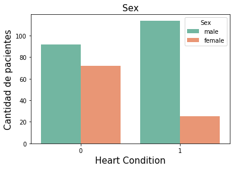

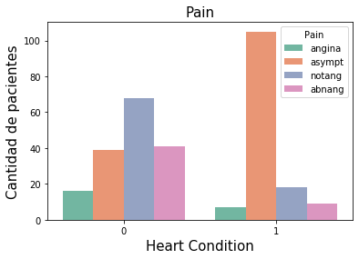

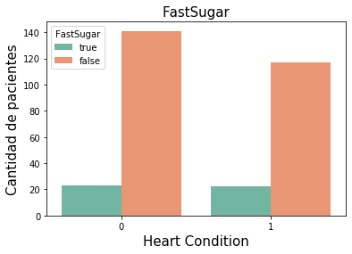

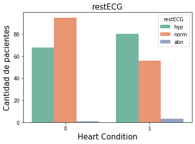

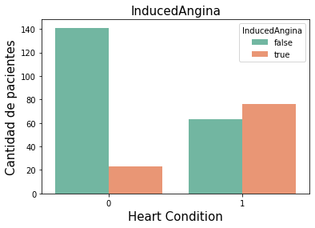

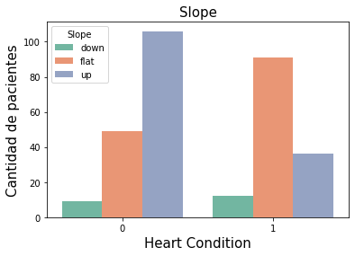

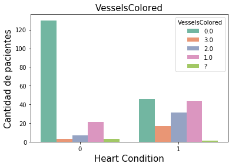

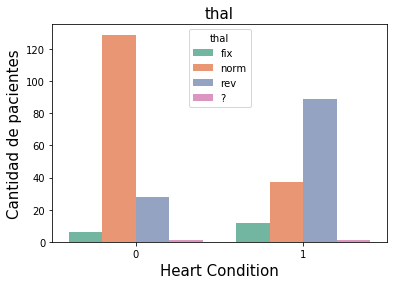

```python
import seaborn as sns
# Las variables categóricas se grafican con countplot
vars=['Sex','Pain','FastSugar','restECG','InducedAngina','Slope','VesselsColored','thal']
for var in vars:
    sns.countplot(x='HeartCondition',data=corazon_graficos,hue=var,palette="Set2")#,figure.facecolor='green')

    plt.xlabel("Heart Condition",size=15)
    plt.ylabel("Cantidad de pacientes", size=15)
    plt.title(var,size=15)
    plt.show()
```

**Se grafican las variables numericas con boxplot**

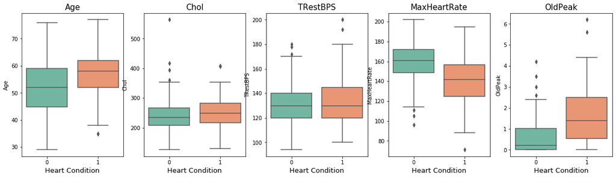

```python
# Las variables numericas se grafican con boxplot

varnum=['Age','Chol','TRestBPS','MaxHeartRate','OldPeak']

plt.figure(figsize=(20,5))
plt.subplot(1,5,1)
sns.boxplot(x='HeartCondition',y='Age',data=corazon_graficos,palette='Set2')
plt.xlabel("Heart Condition",size=13)
plt.ylabel('Age')
plt.title('Age',size=15)

plt.subplot(1,5,2)
sns.boxplot(x='HeartCondition',y='Chol',data=corazon_graficos,palette='Set2')
plt.xlabel("Heart Condition",size=13)
plt.ylabel('Chol')
plt.title('Chol',size=15)

plt.subplot(1,5,3)
sns.boxplot(x='HeartCondition',y='TRestBPS',data=corazon_graficos,palette='Set2')
plt.xlabel("Heart Condition",size=13)
plt.ylabel('TRestBPS')
plt.title('TRestBPS',size=15)

plt.subplot(1,5,4)
sns.boxplot(x='HeartCondition',y='MaxHeartRate',data=corazon_graficos,palette='Set2')
plt.xlabel("Heart Condition",size=13)
plt.ylabel('MaxHeartRate')
plt.title('MaxHeartRate',size=15)

plt.subplot(1,5,5)
sns.boxplot(x='HeartCondition',y='OldPeak',data=corazon_graficos,palette='Set2')
plt.xlabel("Heart Condition",size=13)
plt.ylabel('OldPeak')
plt.title('OldPeak',size=15)

plt.show()
```

**Gráfico de variables numéricas con binning y countplot**

```python
# Se define tipo de dato para poder realizar binning
corazon_graficos[["Age"]] = corazon_graficos[["Age"]].astype("int")
corazon_graficos[["TRestBPS"]] = corazon_graficos[["TRestBPS"]].astype("int")
corazon_graficos[["Chol"]] = corazon_graficos[["Chol"]].astype("int")
corazon_graficos[["MaxHeartRate"]] = corazon_graficos[["MaxHeartRate"]].astype("int")
```

```python
#Binning

bins_Age = np.array ([18,35,55,120])
bins_Chol= np.array([0,200,240,600])
bins_TRestBPS=np.array([90,100,120,140,160,250])
bins_MaxHeartRate= np.array([70,115,160,203])
bins_OldPeak=np.array([0,2,4,6.5])

group_names_Age = ['Joven', 'Edad Media', 'Mayores']
#group_names_Age = [1, 2, 3]
group_names_Chol=['Deseable','Límite','Alto']
#group_names_Chol=[1,2,3]
group_names_TRestBPS=['Bajo','Normal','Prehipertensión','Hipertensión Nivel I','Hipertensión Nivel 22']
#group_names_TRestBPS=[1,2,3,4,5]
group_names_MaxHeartRate=['Bajo','Medio','Alto']
#group_names_MaxHeartRate=[1,2,3]
group_names_OldPeak=['Bajo','Medio','Alto']
#group_names_OldPeak=[1,2,3]


corazon_graficos['Age'] = pd.cut(corazon_graficos['Age'], bins_Age, labels=group_names_Age, include_lowest=True )
corazon_graficos['Chol'] = pd.cut(corazon_graficos['Chol'], bins_Chol, labels=group_names_Chol, include_lowest=True )
corazon_graficos['TRestBPS'] = pd.cut(corazon_graficos['TRestBPS'], bins_TRestBPS, labels=group_names_TRestBPS, include_lowest=True )
corazon_graficos['MaxHeartRate'] = pd.cut(corazon_graficos['MaxHeartRate'], bins_MaxHeartRate, labels=group_names_MaxHeartRate, include_lowest=True )
corazon_graficos['OldPeak'] = pd.cut(corazon_graficos['OldPeak'], bins_OldPeak, labels=group_names_OldPeak, include_lowest=True )

corazon_graficos.head()
```

|  | Age | Sex | Pain | TRestBPS | Chol | FastSugar | restECG | MaxHeartRate | InducedAngina | OldPeak | Slope | VesselsColored | thal | HeartCondition |
| --- | --- | --- | --- | --- | --- | --- | --- | --- | --- | --- | --- | --- | --- | --- |
| 0 | Mayores | male | angina | Hipertensión Nivel I | Límite | true | hyp | Medio | false | Medio | down | 0.0 | fix | 0 |
| 1 | Mayores | male | asympt | Hipertensión Nivel I | Alto | false | hyp | Bajo | true | Bajo | flat | 3.0 | norm | 1 |
| 2 | Mayores | male | asympt | Normal | Límite | false | hyp | Medio | true | Medio | flat | 2.0 | rev | 1 |
| 3 | Edad Media | male | notang | Prehipertensión | Alto | false | norm | Alto | false | Medio | down | 0.0 | norm | 0 |
| 4 | Edad Media | female | abnang | Prehipertensión | Límite | false | hyp | Alto | false | Bajo | up | 0.0 | norm | 0 |

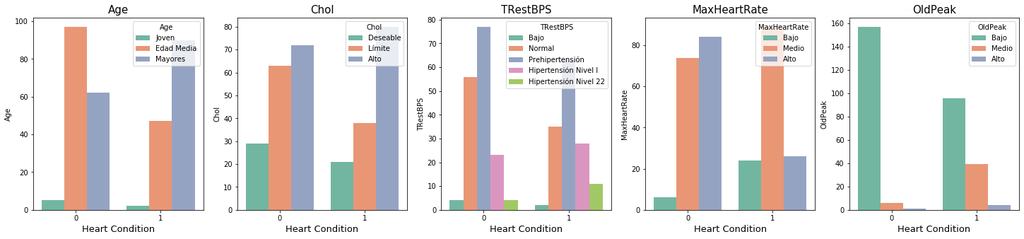

```python
#Grafico de variables numericas luego de aplicar binning

plt.figure(figsize=(25,5))

plt.subplot(1,5,1)
sns.countplot(x='HeartCondition',hue='Age',data=corazon_graficos,palette='Set2')
plt.xlabel("Heart Condition",size=13)
plt.ylabel('Age')
plt.title('Age',size=15)

plt.subplot(1,5,2)
sns.countplot(x='HeartCondition',hue='Chol',data=corazon_graficos,palette='Set2')
plt.xlabel("Heart Condition",size=13)
plt.ylabel('Chol')
plt.title('Chol',size=15)

plt.subplot(1,5,3)
sns.countplot(x='HeartCondition',hue='TRestBPS',data=corazon_graficos,palette='Set2')
plt.xlabel("Heart Condition",size=13)
plt.ylabel('TRestBPS')
plt.title('TRestBPS',size=15)

plt.subplot(1,5,4)
sns.countplot(x='HeartCondition',hue='MaxHeartRate',data=corazon_graficos,palette='Set2')
plt.xlabel("Heart Condition",size=13)
plt.ylabel('MaxHeartRate')
plt.title('MaxHeartRate',size=15)

plt.subplot(1,5,5)
sns.countplot(x='HeartCondition',hue='OldPeak',data=corazon_graficos,palette='Set2')
plt.xlabel("Heart Condition",size=13)
plt.ylabel('OldPeak')
plt.title('OldPeak',size=15)

plt.show()
```

**Histograma con distribución de datos de variables numéricas**

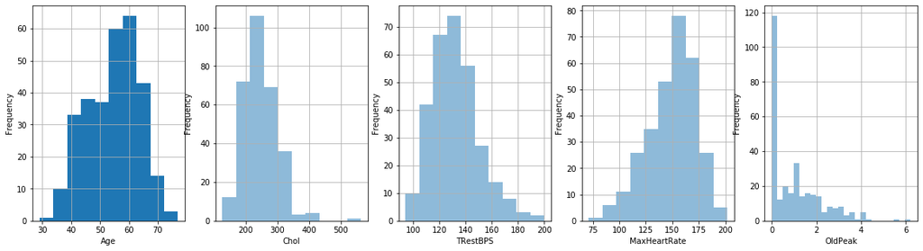

```python
plt.figure(figsize=(20, 5))

plt.subplot(1,5,1)
corazon['Age'].plot.hist(grid = True)
plt.xlabel('Age')

plt.subplot(1,5,2)
corazon['Chol'].plot.hist(alpha=0.5, bins=10, grid = True)
plt.xlabel('Chol')

plt.subplot(1,5,3)
corazon['TRestBPS'].plot.hist(alpha=0.5, bins=10, grid = True)
plt.xlabel('TRestBPS')

plt.subplot(1,5,4)
corazon['MaxHeartRate'].plot.hist(alpha=0.5, bins=10, grid = True)
plt.xlabel('MaxHeartRate')

plt.subplot(1,5,5)
corazon['OldPeak'].plot.hist(alpha=0.5, bins=25, grid = True)
plt.xlabel('OldPeak')

plt.show()
```

## 3- Limpieza y transformación de los datos

#### Se verifica que no haya relación lineal entre las variables del dataset

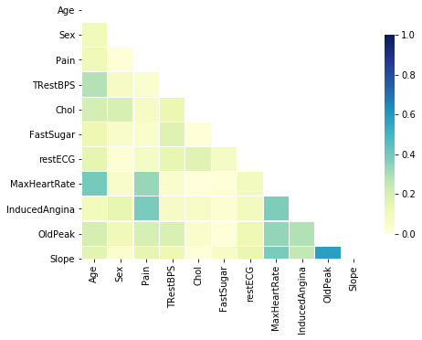

```python
# Compute the correlation matrix
corr = np.abs(corazon.drop(['HeartCondition'], axis=1).corr())

# Generate a mask for the upper triangle
mask = np.zeros_like(corr, dtype=np.bool)
mask[np.triu_indices_from(mask)] = True

# Set up the matplotlib figure
f, ax = plt.subplots(figsize=(7, 5))

# Draw the heatmap with the mask and correct aspect ratio
sns.heatmap(corr, mask=mask, vmin = 0.0, vmax=1.0, center=0.5,
            linewidths=.1, cmap="YlGnBu", cbar_kws={"shrink": .8})
```

**Identificacion de datos faltantes**

```python
#Se reemplazan los signos de pregunta por NaN para poder identificar los valores faltantes
import numpy as np
corazon.replace("?",np.NaN,inplace=True)

#Se totalizan los valores faltantes por categoría
datos_faltantes=corazon.isnull()
datos_faltantes.sum(axis=0)
```

```
Age               0
Sex               0
Pain              0
TRestBPS          0
Chol              0
FastSugar         0
restECG           0
MaxHeartRate      0
InducedAngina     0
OldPeak           0
Slope             0
VesselsColored    4
thal              2
HeartCondition    0
dtype: int64
```

Se observa que faltan 4 valores para VesselsColored y 2 para thal.

**Se reemplazan los valores faltantes de las variables categóricas por la moda:**

- thal

```python
#Variable thal
corazon['thal'].value_counts()
```

```
3.0    166
7.0    117
6.0     18
Name: thal, dtype: int64
```

La moda de de thal es 3.0

```python
# Se reemplaza los valores faltantes de thal la moda hallada.
corazon['thal'].replace(np.NaN,"3.0",inplace=True)
```

- VesselsColored

```python
#Variable VesselsColored
corazon['VesselsColored'].value_counts()
```

```
0.0    176
1.0     65
2.0     38
3.0     20
Name: VesselsColored, dtype: int64
```

```python
# Se reemplaza los valores faltantes de VesslesColored por la moda hallada.
corazon['VesselsColored'].replace(np.nan,"0.0",inplace=True)
```

```python
#Se verifica que no hayan quedado valores faltantes
missing_data=corazon.isnull()
missing_data.sum(axis=0)
```

```
Age               0
Sex               0
Pain              0
TRestBPS          0
Chol              0
FastSugar         0
restECG           0
MaxHeartRate      0
InducedAngina     0
OldPeak           0
Slope             0
VesselsColored    0
thal              0
HeartCondition    0
dtype: int64
```

**Modificación de tipo de dato**

```python
# Se convierten las variables numéricas en entero (int) (excepto OldPeak)

corazon[["Age"]] = corazon[["Age"]].astype("int")
corazon[["Sex"]] = corazon[["Sex"]].astype("int")
corazon[["Pain"]] = corazon[["Pain"]].astype("int")
corazon[["TRestBPS"]] = corazon[["TRestBPS"]].astype("int")
corazon[["Chol"]] = corazon[["Chol"]].astype("int")
corazon[["FastSugar"]] = corazon[["FastSugar"]].astype("int")
corazon[["restECG"]] = corazon[["restECG"]].astype("int")
corazon[["MaxHeartRate"]] = corazon[["MaxHeartRate"]].astype("int")
corazon[["InducedAngina"]] = corazon[["InducedAngina"]].astype("int")
corazon[["Slope"]] = corazon[["Slope"]].astype("int")
corazon[["VesselsColored"]] = corazon[["VesselsColored"]].astype("float")
corazon[["thal"]] = corazon[["thal"]].astype("float")
corazon[["HeartCondition"]] = corazon[["HeartCondition"]].astype("int")
corazon[["VesselsColored"]] = corazon[["VesselsColored"]].astype("int")
corazon[["thal"]] = corazon[["thal"]].astype("int")
```

```python
#Se verifican los tipos de datos resultantes
corazon.dtypes
```

```
Age                 int32
Sex                 int32
Pain                int32
TRestBPS            int32
Chol                int32
FastSugar           int32
restECG             int32
MaxHeartRate        int32
InducedAngina       int32
OldPeak           float64
Slope               int32
VesselsColored      int32
thal                int32
HeartCondition      int32
dtype: object
```

#### **Transformación de variables categóricas multiclase**

Un indicador o variable dummy es una variable numérica utilizada para etiquetar categorías. Pueeden ser binarias, o representar catagorías mútiples.

Se convertirán Pain, thal y Slope que son multiclase.

```python
corazon=pd.get_dummies(corazon,columns=['Pain','thal','Slope'])
corazon.head()
```

|  | Age | Sex | TRestBPS | Chol | FastSugar | restECG | MaxHeartRate | InducedAngina | OldPeak | VesselsColored | ... | Pain_1 | Pain_2 | Pain_3 | Pain_4 | thal_3 | thal_6 | thal_7 | Slope_1 | Slope_2 | Slope_3 |
| --- | --- | --- | --- | --- | --- | --- | --- | --- | --- | --- | --- | --- | --- | --- | --- | --- | --- | --- | --- | --- | --- |
| 0 | 63 | 1 | 145 | 233 | 1 | 2 | 150 | 0 | 2.3 | 0 | ... | 1 | 0 | 0 | 0 | 0 | 1 | 0 | 0 | 0 | 1 |
| 1 | 67 | 1 | 160 | 286 | 0 | 2 | 108 | 1 | 1.5 | 3 | ... | 0 | 0 | 0 | 1 | 1 | 0 | 0 | 0 | 1 | 0 |
| 2 | 67 | 1 | 120 | 229 | 0 | 2 | 129 | 1 | 2.6 | 2 | ... | 0 | 0 | 0 | 1 | 0 | 0 | 1 | 0 | 1 | 0 |
| 3 | 37 | 1 | 130 | 250 | 0 | 0 | 187 | 0 | 3.5 | 0 | ... | 0 | 0 | 1 | 0 | 1 | 0 | 0 | 0 | 0 | 1 |
| 4 | 41 | 0 | 130 | 204 | 0 | 2 | 172 | 0 | 1.4 | 0 | ... | 0 | 1 | 0 | 0 | 1 | 0 | 0 | 1 | 0 | 0 |

5 rows × 21 columns

## 4- Modelos de predicción

Se separa la variable dependiente (HeartCondition) de las variables independientes.

```python
#Se define variable a predecir
y=corazon['HeartCondition'].values.copy()

#Se definen las variables independientes
X=corazon.drop(['HeartCondition'],1)
```

División del conjunto de datos en entrenamiento (80%) y test (20%):

```python
#Se divide el conjunto de datos en entrenamiento y test (train y test)
#NOTA: en todas las metodologías tengo que hacer esta división. Luego puede ser que los de train los subdivida en train y validation, o los subdivida en kfols, o nada (hold out).
from sklearn.model_selection import train_test_split
X_train, X_test, y_train, y_test = train_test_split(X, y, test_size=0.2, random_state=22)
```

Normalización de los datos:

```python
#Normalización de los datos
from sklearn.preprocessing import StandardScaler

scaler = StandardScaler();
X_train_scaled = scaler.fit_transform(X_train)
X_test_scaled = scaler.transform(X_test)
```

### A- Regresión logística

**Selección del hiperaparámetro C por validación cruzada:**

```
best mean cross-validation score: 0.835
best parameters: {'C': 0.2976351441631313}
```

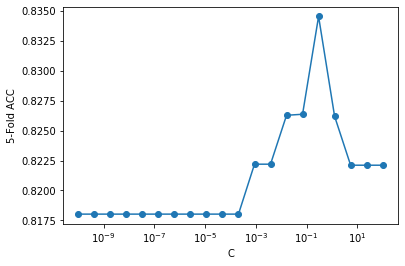

```python
#Se importa el modelo a utilizar
from sklearn.linear_model import LogisticRegression

#Se importa GridSearchCV para encontrar el mejor hiperparámetro
from sklearn.model_selection import GridSearchCV

#grilla de valores C posibles
vectorC = np.logspace(-10, 2, 20)
param_grilla = {'C': vectorC}
n_folds = 5

#Se crea la grilla
grilla = GridSearchCV(LogisticRegression(fit_intercept=False, solver='liblinear'), scoring='accuracy', param_grid=param_grilla, cv=n_folds)

#Se ajusta la grilla con datos de entrenamiento:
grilla.fit(X_train_scaled, y_train)
print("best mean cross-validation score: {:.3f}".format(grilla.best_score_))
print("best parameters: {}".format(grilla.best_params_))
#print("test-set score: {:.2f}".format(grilla.score(X_test, y_test)))

scores = np.array(grilla.cv_results_['mean_test_score'])
plt.semilogx(vectorC, scores, '-o')
plt.xlabel('C')
plt.ylabel('5-Fold ACC')
plt.show()
```

El valor óptimo de C hallado fue 0,29.

**Se evalúa el modelo con el mejor hiperparámetro (C=0.29)**

```python
#Se define el modelo con el hipeparámetro hallado:
modeloRL=LogisticRegression(C=0.29,max_iter=100,solver='liblinear') #'liblinear'

#Se entrena el modelo
modeloRL.fit(X_train_scaled, y_train)

#Se evalúa la precisión:
print('Precisión en entrenamiento:',modeloRL.score(X_train_scaled,y_train))
print('Precisión en test:',modeloRL.score(X_test_scaled,y_test))

#Se agregan los resultados a las listas "entrenamiento" y "test" para su posterior visualización
names=['RL']
entrenamiento=[modeloRL.score(X_train_scaled,y_train)]
test=[modeloRL.score(X_test_scaled,y_test)]
```

```
Precisión en entrenamiento: 0.8636363636363636
Precisión en test: 0.8852459016393442
```

Se obtuvo un 86,36% de precisión en el conjunto de datos de entrenamiento y 88,52% en el conjunto de datos de test. Se observa que el modelo se ajusta bien y de forma similar en los conjuntos de entrenamiento y de test. El modelo está generalizando bien.

**Se verifican los resultados obtenidos con validación cruzada en el conjunto completo de datos.**

```python
from sklearn.model_selection import cross_validate
scoring = ['accuracy']
cv_results = cross_validate(modeloRL, X, y, cv=5, return_train_score=True, return_estimator=True, scoring=scoring)
cv_results
```

```
{'fit_time': array([0.01000023, 0.00500035, 0.00499988, 0.00499988, 0.01000023]),
 'score_time': array([0.00499988, 0.00499988, 0.00500011, 0.00499988, 0.00499988]),
 'estimator': (LogisticRegression(C=0.29, solver='liblinear'),
  LogisticRegression(C=0.29, solver='liblinear'),
  LogisticRegression(C=0.29, solver='liblinear'),
  LogisticRegression(C=0.29, solver='liblinear'),
  LogisticRegression(C=0.29, solver='liblinear')),
 'test_accuracy': array([0.85245902, 0.90163934, 0.81967213, 0.83333333, 0.75      ]),
 'train_accuracy': array([0.87603306, 0.86363636, 0.88016529, 0.86419753, 0.89300412])}
```

**Importancia relativa de variables**

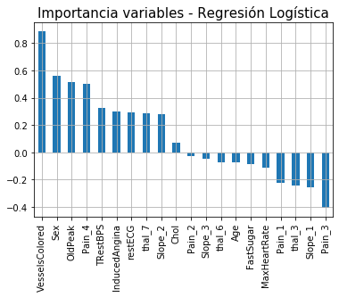

```python
#Comparación importancia relativa de las variables
cols=['Age', 'Sex', 'TRestBPS', 'Chol', 'FastSugar', 'restECG','MaxHeartRate', 'InducedAngina', 'OldPeak', 'VesselsColored','Pain_1','Pain_2','Pain_3','Pain_4','thal_3','thal_6','thal_7','Slope_1','Slope_2','Slope_3']

cf_RL=modeloRL.coef_
feat_importanceRL=pd.Series(cf_RL[0,:], index=cols)
feat_importanceRL.nlargest(21).plot(kind='bar', grid=True)
plt.title('Importancia variables - Regresión Logística', size=15)
#pd.Series(cf[0,:]).plot.bar()
#plt.title('Importancia relativa de las variables - Modelo Regresión logística')
#plt.show()
```

### B - Arbol de decisión

**Selección de hiperparámetros**

```python
from sklearn.tree import DecisionTreeClassifier
from sklearn.metrics import accuracy_score

max_depth = np.arange(1, 16, 1) # rejilla de valores posibles que queremos explorar
min_samples_leaf=[1,2,3,4,5]
param_grid = {'max_depth': max_depth,'min_samples_leaf':[1,2,3,4,5,6,7]}

n_folds = 5
grid = GridSearchCV(DecisionTreeClassifier(),
                    scoring='accuracy',
                    param_grid=param_grid,
                    cv=5,
                    return_train_score=True)

grid.fit(X_train_scaled, y_train)
print("best mean cross-validation score: {:.3f}".format(grid.best_score_))
print("best parameters: {}".format(grid.best_params_))
```

```
best mean cross-validation score: 0.789
best parameters: {'max_depth': 3, 'min_samples_leaf': 4}
```

**Definición del modelo, entrenamiento y validación**

```python
#Se define el modelo "modelo_arbol"
modelo_arbol=DecisionTreeClassifier(min_samples_leaf=5, max_depth=3)

#Se entrena el modelo
modelo_arbol.fit(X_train,y_train)

#Se evalúa la precisión
print('Precisión entrenamiento:',modelo_arbol.score(X_train_scaled,y_train)) # Revisar si corresponde escalado
print('Precisión validación:',modelo_arbol.score(X_test_scaled,y_test))

#Se agregan los resultados a las listas "entrenamiento" y "test" para su posterior visualización
names.append('Arbol')
entrenamiento.append(modelo_arbol.score(X_train_scaled,y_train))
test.append(modelo_arbol.score(X_test_scaled,y_test))
```

```
Precisión entrenamiento: 0.7892561983471075
Precisión validación: 0.819672131147541
```

La precisión en el conjunto de datos de entrenamiento es de 78,92% y en el conjunto de datos de test es 81,97%. No se observa sobreajuste en el modelo y generaliza bien.

**Se verifican los resultados obtenidos con validación cruzada en el conjunto completo de datos.**

```python
from sklearn.model_selection import cross_validate
scoring = ['accuracy']
cv_results = cross_validate(modelo_arbol, X, y, cv=5, return_train_score=True, return_estimator=True, scoring=scoring)
cv_results
```

```
{'fit_time': array([0.00999975, 0.00999999, 0.00999999, 0.        , 0.00500011]),
 'score_time': array([0.00500011, 0.00499988, 0.        , 0.00500011, 0.        ]),
 'estimator': (DecisionTreeClassifier(max_depth=3, min_samples_leaf=5),
  DecisionTreeClassifier(max_depth=3, min_samples_leaf=5),
  DecisionTreeClassifier(max_depth=3, min_samples_leaf=5),
  DecisionTreeClassifier(max_depth=3, min_samples_leaf=5),
  DecisionTreeClassifier(max_depth=3, min_samples_leaf=5)),
 'test_accuracy': array([0.78688525, 0.90163934, 0.80327869, 0.75      , 0.76666667]),
 'train_accuracy': array([0.84297521, 0.83471074, 0.86363636, 0.85185185, 0.87654321])}
```

**Importancia relativa de las variables:**

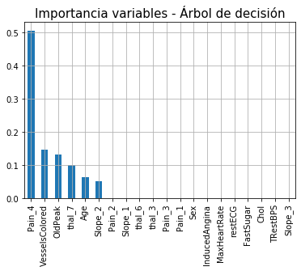

```python
#cols=['Age', 'Sex', 'TRestBPS', 'Chol', 'FastSugar', 'restECG','MaxHeartRate', 'InducedAngina', 'OldPeak', 'VesselsColored','11 Pain_1','Pain_2','Pain_3','Pain_4','thal_3','thal_6','thal_7','Slope_1','Slope_2','Slope_3']

cf_Arbol=modelo_arbol.feature_importances_
feat_importanceAR=pd.Series(cf_Arbol, index=cols)
feat_importanceAR.nlargest(21).plot(kind='bar', grid=True)
plt.title('Importancia variables - Árbol de decisión', size=15)
```

### C- KNN

**Búsqueda de mejor hiperparámetro**

```
best mean cross-validation score: 0.839
best parameters: {'n_neighbors': 16}
```

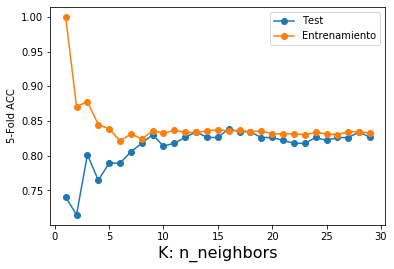

```python
#Se importa el modelo
from sklearn.neighbors import KNeighborsClassifier

n_neighbors = [1,2,3,4,5,6,7,8,9,10,11,12,13,14,15,16,17,18,19,20,21,22,23,24,25,26,27,28,29]
param_grid = {'n_neighbors': n_neighbors}

n_folds = 5
grid = GridSearchCV(KNeighborsClassifier(),

                    param_grid=param_grid,
                    cv=5,
                    return_train_score=True)

grid.fit(X_train_scaled, y_train)
print("best mean cross-validation score: {:.3f}".format(grid.best_score_))
print("best parameters: {}".format(grid.best_params_))

scores_test = np.array(grid.cv_results_['mean_test_score'])
scores_train = np.array(grid.cv_results_['mean_train_score'])
plt.plot(n_neighbors, scores_test,'-o', label='Test')
plt.plot(n_neighbors, scores_train, '-o', label='Entrenamiento')
plt.xlabel('K: n_neighbors', fontsize=16)
plt.ylabel('{}-Fold ACC'.format(n_folds))
plt.legend(loc='best')
plt.show()
```

**Definición del modelo, entrenamiento y validación**

```python
#Se importa el modelo
from sklearn.neighbors import KNeighborsClassifier
#Se configura el modelo 'modelo_knn' con hiperparámetro n_neighbors=3
modelo_knn3=KNeighborsClassifier(n_neighbors=3)
#Se entrena el modelo
modelo_knn3.fit(X_train_scaled,y_train)

#Se evalúa la precisión en conjunto de datos de entrenamiento y de test.
print('Precisión en entrenamiento:',modelo_knn3.score(X_train_scaled,y_train))
print('Precisión en test:',modelo_knn3.score(X_test_scaled,y_test))

#Se agregan los resultados a las listas "entrenamiento" y "test" para su posterior visualización
names.append('KNN')
entrenamiento.append(modelo_knn3.score(X_train_scaled,y_train))
test.append(modelo_knn3.score(X_test_scaled,y_test))
```

```
Precisión en entrenamiento: 0.8760330578512396
Precisión en test: 0.8688524590163934
```

### D- SVM

```python
from sklearn.svm import SVC

vectorC = np.logspace(-3, 3, 21)
vectorG = np.logspace(-5, 1, 21)

#param_grid = [{'C': c_values,'kernel':['linear']},
 #            {'C':c_values,'kernel':['rbf']}]

#param_grid=[{'kernel':kernel}]
#param_grid=[{'C':c_values},{'gamma':gamma

param_grid = [
  {'C': [1, 100, 1000], 'kernel': ['linear']},
  {'C': [1, 100, 1000], 'gamma': [0.1,0.01,0.001, 0.0001], 'kernel': ['rbf']},
 ]

n_folds = 5
grid = GridSearchCV(SVC(kernel='rbf'),

                    param_grid=param_grid,
                    cv=5,
                    return_train_score=True)

grid.fit(X_train_scaled, y_train)
print("best mean cross-validation score: {:.3f}".format(grid.best_score_))
print("best parameters: {}".format(grid.best_params_))

#scores_test = np.array(grid.cv_results_['mean_test_score'])
#scores_train = np.array(grid.cv_results_['mean_train_score'])
#plt.plot(c_values, scores_test,'-o', label='Test')
#plt.plot(c_values, scores_train, '-o', label='Entrenamiento')
#plt.xlabel('C', fontsize=16)
#plt.ylabel('{}-Fold ACC'.format(n_folds))
#plt.legend(loc='best')
#plt.show()
```

```
best mean cross-validation score: 0.826
best parameters: {'C': 1, 'gamma': 0.01, 'kernel': 'rbf'}
```

Los hiperparámetros óptimos resultaron: C=1, gamma=0.01 y Kernel=rbf.

**Definición del modelo, entrenamiento y validación con hiperparámetros óptimos**

```python
# Se importa el modelo
from sklearn.svm import SVC

# Se define el modelo
modelo_svm=SVC(C=1,gamma=0.01,kernel='rbf')#random_state=1)

#Se entrena el modelo
modelo_svm.fit(X_train_scaled,y_train)

#Se evalúa la precisión en el conjunto de datos de entrenamiento y de test
print('Precisión en entrenamiento:',modelo_svm.score(X_train_scaled,y_train))
print('Precisión en test:',modelo_svm.score(X_test_scaled,y_test))

#Se agregan los resultados a las listas "entrenamiento" y "test" para su posterior visualización
names.append('SVM')
entrenamiento.append(modelo_svm.score(X_train_scaled,y_train))
test.append(modelo_svm.score(X_test_scaled,y_test))
```

```
Precisión en entrenamiento: 0.8677685950413223
Precisión en test: 0.9180327868852459
```

Se obtuvo una precisión de 86,77% en el conjuntos de datos de entrenamiento y 91,80% en el conjunto de datos de test.

### E- Naive Bayes Algorithm

```python
# Se importa el modelo
from sklearn.naive_bayes import GaussianNB

# Se define el modelo
modelo_nb=GaussianNB()

# Se entrena el modelo
modelo_nb.fit(X_train_scaled,y_train)

# Se evalúa la precisión en el conjunto de datos de entrenamiento y de test
print('Métrica en entrenamiento:',modelo_nb.score(X_train_scaled,y_train))
print('Métrica en entrenamiento:',modelo_nb.score(X_test_scaled,y_test))

#Se agregan los resultados a las listas "entrenamiento" y "test" para su posterior visualización
names.append('Naive Bayes')
entrenamiento.append(modelo_nb.score(X_train_scaled,y_train))
test.append(modelo_nb.score(X_test_scaled,y_test))
```

```
Métrica en entrenamiento: 0.8388429752066116
Métrica en entrenamiento: 0.9016393442622951
```

La precisión obtenida con el modelo Naive Bayes fue 83,88% en el conjunto de datos de entrenamiento y 90,16% en el de test.

### XGBoost

**Selección de hiperparámetros**

```python
from xgboost import XGBClassifier

#Se define el modelo
modelo_XGB=XGBClassifier(max_depth=2,n_estimators=100,learning_rate=0.05)

estimator = XGBClassifier(
    objective= 'binary:logistic',
    nthread=4,
    seed=42)

parameters = {
    'max_depth': range (2, 10, 1),
    'n_estimators': range(60, 220, 40),
    'learning_rate': [0.1, 0.01, 0.05]
}

grid = GridSearchCV(
    estimator=estimator,
    param_grid=parameters,
    scoring = 'roc_auc',
    n_jobs = 10,
    cv = 5,
    verbose=True
)

grid.fit(X_train_scaled, y_train)
print("best mean cross-validation score: {:.3f}".format(grid.best_score_))
print("best parameters: {}".format(grid.best_params_))
```

```
Fitting 5 folds for each of 96 candidates, totalling 480 fits
```

```
[Parallel(n_jobs=10)]: Using backend LokyBackend with 10 concurrent workers.
[Parallel(n_jobs=10)]: Done  30 tasks      | elapsed:   18.8s
[Parallel(n_jobs=10)]: Done 180 tasks      | elapsed:   25.9s
[Parallel(n_jobs=10)]: Done 430 tasks      | elapsed:   39.3s
```

```
best mean cross-validation score: 0.895
best parameters: {'learning_rate': 0.05, 'max_depth': 2, 'n_estimators': 100}
```

```
[Parallel(n_jobs=10)]: Done 480 out of 480 | elapsed:   42.0s finished
```

**Definición del modelo, entrenamiento y validación con parámetros óptimos**

```python
#pip install xgboost
#Se importa el modelo XGBoost
#from xgboost import XGBClassifier

#Se define el modelo
modelo_XGB=XGBClassifier(max_depth=2,n_estimators=100,learning_rate=0.05)

#Se entrena el modelo
modelo_XGB.fit(X_train_scaled, y_train)

# Se evalúa la precisión en el conjunto de datos de entrenamiento y de test
print('Métrica en entrenamiento:',modelo_XGB.score(X_train_scaled,y_train))
print('Métrica en entrenamiento:',modelo_XGB.score(X_test_scaled,y_test))

#Se agregan los resultados a las listas "entrenamiento" y "test" para su posterior visualización
names.append('XGBoost')
entrenamiento.append(modelo_XGB.score(X_train_scaled,y_train))
test.append(modelo_XGB.score(X_test_scaled,y_test))
```

```
Métrica en entrenamiento: 0.8884297520661157
Métrica en entrenamiento: 0.8524590163934426
```

La precisión obtenida con XGBoost fue 88,84% en el conjunto de datos de entrenamiento y 85,24% en test.

## 5 - Evaluación comparativa de los modelos - Gráfico de barras

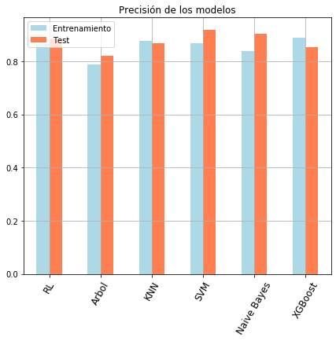

```python
plotdata=pd.DataFrame({
    "Entrenamiento":entrenamiento,
    "Test":test
    },
    index=names)

plotdata.plot(kind="bar",grid=True, color=['lightblue','coral'],figsize=(7,6))
plt.title("Precisión de los modelos")
plt.xticks(size=12,rotation=60)
plt.show()
```

## 6- Evaluación con Matriz de confusión

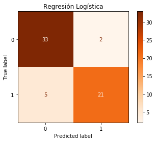

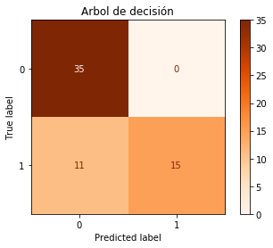

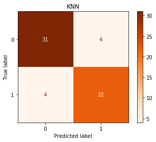

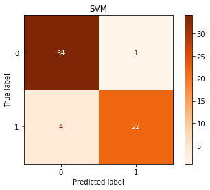

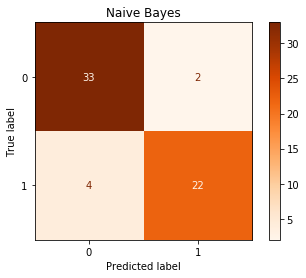

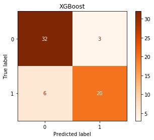

```python
from sklearn.metrics import plot_confusion_matrix
#plt.figure(figsize=(20,20))

plot_confusion_matrix(modeloRL,X_test_scaled,y_test,cmap=plt.cm.Oranges)
plt.title('Regresión Logística')

plot_confusion_matrix(modelo_arbol,X_test_scaled,y_test,cmap=plt.cm.Oranges)
plt.title('Arbol de decisión')
#plot_confusion_matrix(modelo_ElNet,X_test_scaled,y_test,cmap=plt.cm.Blues)
plot_confusion_matrix(modelo_knn3,X_test_scaled,y_test,cmap=plt.cm.Oranges)
plt.title('KNN')
plot_confusion_matrix(modelo_svm,X_test_scaled,y_test,cmap=plt.cm.Oranges)
plt.title('SVM')
plot_confusion_matrix(modelo_nb,X_test_scaled,y_test,cmap=plt.cm.Oranges)
plt.title('Naive Bayes')

plot_confusion_matrix(modelo_XGB,X_test_scaled,y_test,cmap=plt.cm.Oranges)
plt.title('XGBoost')

plt.show()
```

## 7- Comparación de algoritmos con conjunto completo de datos - Gráfico Boxplot

```python
from sklearn import model_selection
models = []
models.append(('LR', LogisticRegression(C=0.29,max_iter=100,solver='liblinear')))
models.append(('ARBOL', DecisionTreeClassifier(min_samples_leaf=5, max_depth=3)))
models.append(('KNN', KNeighborsClassifier(n_neighbors=16)))
models.append(('SVM', SVC(C=1,gamma=0.01,kernel='rbf')))
models.append(('NB', GaussianNB()))
models.append(('XGB', XGBClassifier(max_depth=2,n_estimators=100,learning_rate=0.05)))

# Se evalúa cada modelo con cross validation
results = []
names = []
scoring='accuracy'
for name, model in models:
    kfold = model_selection.KFold(n_splits=5)
    cv_results = model_selection.cross_val_score(model, X_train_scaled, y_train, cv=kfold, scoring=scoring)
    results.append(cv_results)
    names.append(name)
    msg = "%s: %f (%f)" % (name, cv_results.mean(), cv_results.std())
    print(msg)
```

```
LR: 0.826276 (0.031949)
ARBOL: 0.772874 (0.042707)
KNN: 0.838776 (0.036074)
SVM: 0.826446 (0.033782)
NB: 0.817857 (0.047076)
XGB: 0.801701 (0.040443)
```

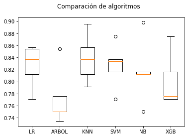

```python
# Comparación de algoritmos
fig = plt.figure()
fig.suptitle('Comparación de algoritmos')
ax = fig.add_subplot(111)
plt.boxplot(results)
ax.set_xticklabels(names)
plt.show()
```